# La poule qui chante

Marion Coutarel

** Libraries**

```r
library(ggplot2)
library(gplots)
library("FactoMineR")
library("factoextra")
library(rgl)
library("corrplot")
library("psych")
library(RColorBrewer)
library(dendextend)
library("choroplethr")
library(tidyverse)
library(tibble)
```

## Data set

To determine countries that where worth investing in, we create a dataset with datas from FAO, WTO, European Union… This part of the job was done with python.

We choose datas :

- that describe the country:
  - population
  - GDP per capita
  - share of urban population
- that show its economics stability
  - Currency volatility
  - food price volatility
  - logistic score
  - number of days to start a business
- that indicate its involvement in global poultry meat trade
  - propensity to import
  - average duty (frozen cut meat)
- that give indication concerning the poultry meat consumption
  - domestic aviability
  - poultry share in meat consumption

```r
data<-read.table("data/dataset_P9.csv", header=T, sep=',', encoding='utf-8')
data <- subset(data, data$Country!='Venezuela, Bolivarian Republic of') # removed as it is a big outlier

rownames(data)<-data$Country
data$Country<- NULL
data$X<-NULL
data2 <-data[2:(length(data)-1)]
```

We get a dataset of 161 countries with 11 quantitative variables.

## Correlations

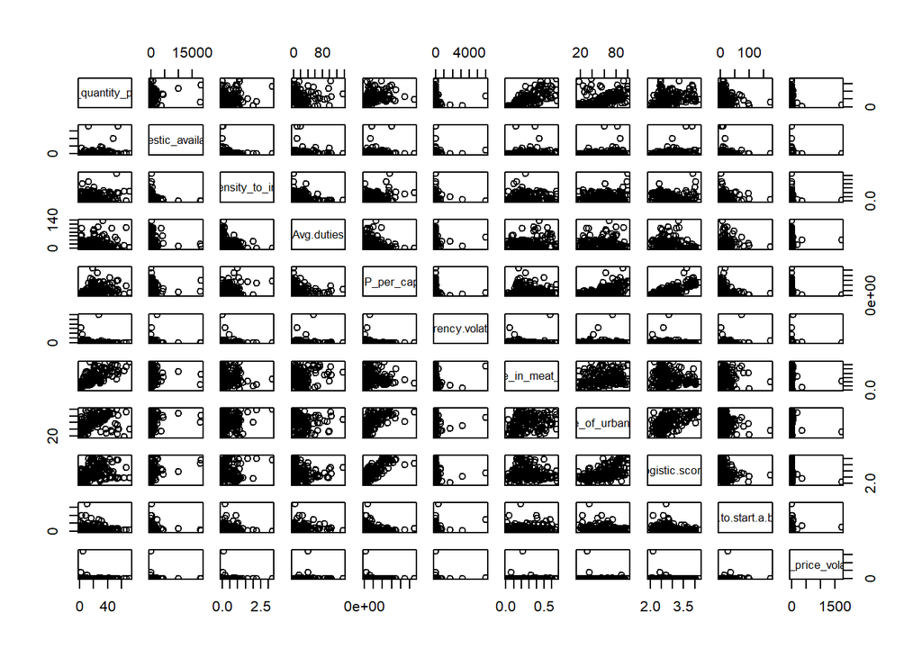

```r
pairs(data2[,1:11])
```

Graphicaly we see that some of this variables seems to be correlated. We need to build the correlation matrix.

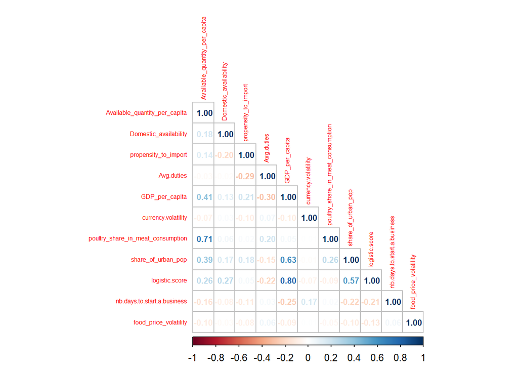

```r
corr.matrix<- cor(data2[,1:11])
corrplot(corr.matrix, method = "number", tl.cex=0.5,number.cex=0.7, type="lower")
```

We can see some good correlation between some variables (share of poultry in meat consumption with aviabale quantity per capita or logistic score and urban population with GDP per capita). But is it sufficient to run an PCA?

As the determinant of correlation matrix ( 0.031456 ) is different from 1 we can say that we do not work with an identity matrix. According to bartlett test, as p-value is 2.0340422^{-80}, our matrix is significantly different from identity matrix and we can start to work on a *PCA*.

```r
KMO(corr.matrix)
```

```
## Kaiser-Meyer-Olkin factor adequacy
## Call: KMO(r = corr.matrix)
## Overall MSA =  0.63
## MSA for each item =
##     Available_quantity_per_capita             Domestic_availability
##                              0.58                              0.54
##              propensity_to_import                        Avg.duties
##                              0.58                              0.65
##                    GDP_per_capita               currency.volatility
##                              0.68                              0.63
## poultry_share_in_meat_consumption                share_of_urban_pop
##                              0.44                              0.80
##                    logistic.score       nb.days.to.start.a.business
##                              0.66                              0.71
##             food_price_volatility
##                              0.70
```

The MSA indicator (>0,6) is not excellent on our matrix but still we can sum up data. The worsening indicator is poultry share in meat consumption but as it is quite highly correlated with avaibility per capita we should keep it.

## PCA

```r
res.PCA <-PCA(data2, scale.unit = TRUE, ncp = 6, graph = F)
eig.value <- get_eigenvalue(res.PCA)
eig.value
```

```
##        eigenvalue variance.percent cumulative.variance.percent
## Dim.1   2.9863957        27.149052                    27.14905
## Dim.2   1.6657043        15.142766                    42.29182
## Dim.3   1.3188130        11.989209                    54.28103
## Dim.4   1.0777090         9.797355                    64.07838
## Dim.5   0.9694488         8.813171                    72.89155
## Dim.6   0.8549829         7.772572                    80.66413
## Dim.7   0.7814444         7.104040                    87.76817
## Dim.8   0.5796513         5.269557                    93.03772
## Dim.9   0.4354343         3.958494                    96.99622
## Dim.10  0.1740938         1.582671                    98.57889
## Dim.11  0.1563223         1.421112                   100.00000
```

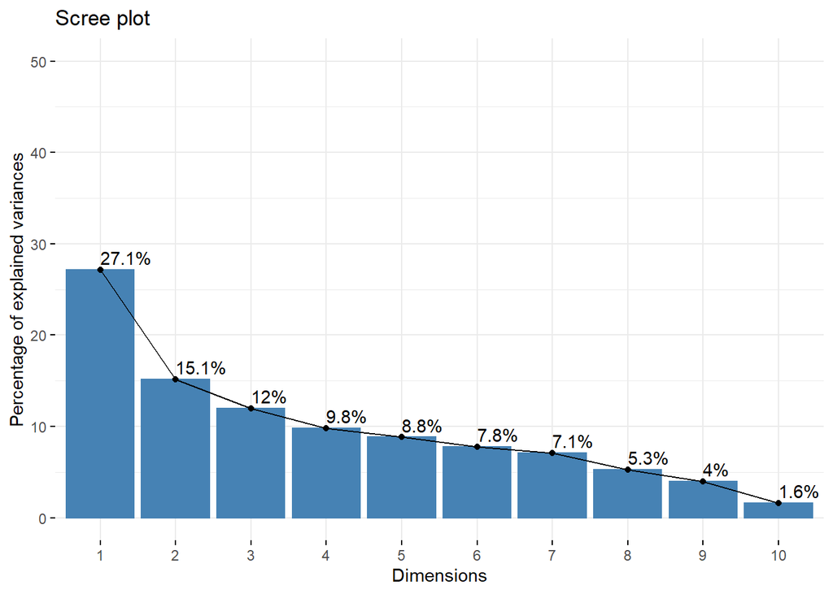

```r
fviz_eig(res.PCA, addlabels = TRUE, ylim = c(0, 50))
```

If we keep only eigen values > 1, we would explain **64% inertia** with 4 dimensions. This is not much. If we want to explain more than **80% of inertia** we should keep 6 dimensions.

### Dimensions

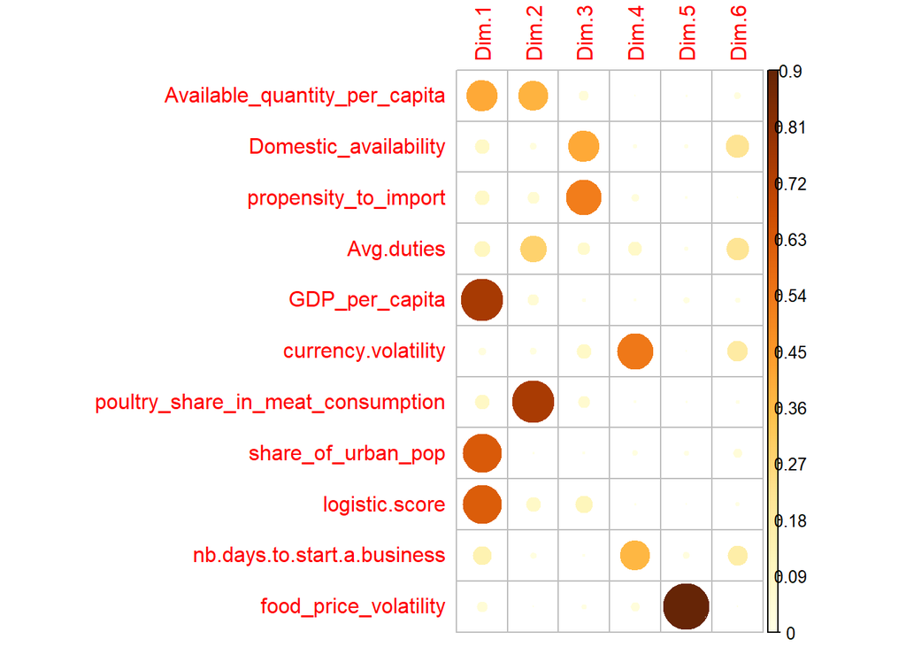

```r
var <- get_pca_var(res.PCA)


# Cos2: quality of representation

corrplot(var$cos2, is.corr=FALSE)
```

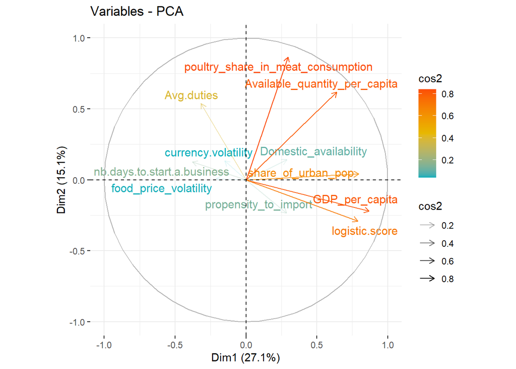

```r
fviz_pca_var(res.PCA, col.var = "cos2",alpha.var ="cos2",
             gradient.cols = c("#00AFBB", "#E7B800", "#FC4E07"),repel = TRUE # ?vite le chevauchement de texte
)
```

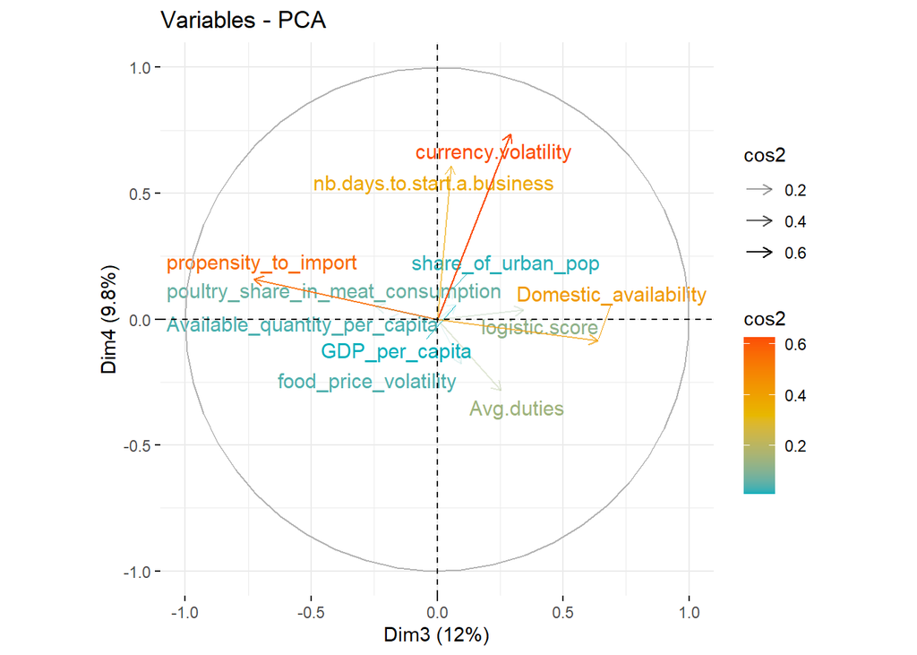

```r
fviz_pca_var(res.PCA, col.var = "cos2",alpha.var ="cos2",
             gradient.cols = c("#00AFBB", "#E7B800", "#FC4E07"),axes=3:4,repel = TRUE # évite le chevauchement de texte
)
```

If we try to interpret dimensions, we should have a look at variable contributions to dimensions.

- **dimensions 1** can be seen as a indicator of country development

First dimension seems really interesting for our purpose. **Countries high on this axis** will have a good revenu per habitant with a high population density, a good logistic score and propensity to import with low duties and good economic stability which could **mean an easy and cheap access to solvent customers** .

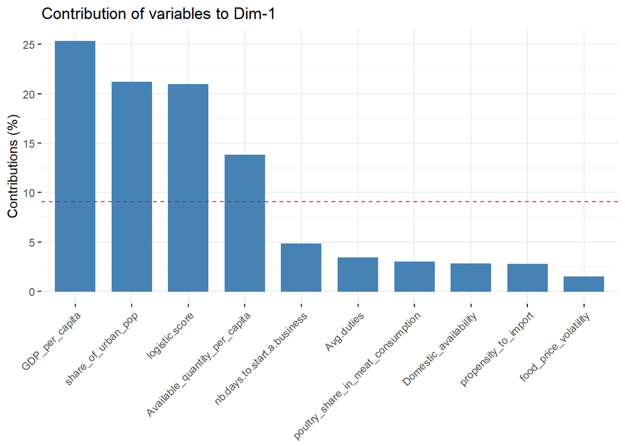

```r
fviz_contrib(res.PCA, choice = "var", axes = 1, top = 10)
```

```r
dimdesc <- dimdesc(res.PCA, axes=1, proba=0.05) #give correlation of variable to the dimension and p value
print(dimdesc$Dim.1)
```

```
## $quanti
##                                   correlation      p.value
## GDP_per_capita                      0.8693876 1.518254e-50
## share_of_urban_pop                  0.7950939 2.328815e-36
## logistic.score                      0.7899922 1.320410e-35
## Available_quantity_per_capita       0.6414757 4.841405e-20
## poultry_share_in_meat_consumption   0.2972966 1.282266e-04
## Domestic_availability               0.2878065 2.138703e-04
## propensity_to_import                0.2862870 2.317430e-04
## food_price_volatility              -0.2097820 7.565220e-03
## Avg.duties                         -0.3172548 4.121042e-05
## nb.days.to.start.a.business        -0.3775937 7.899541e-07
##
## attr(,"class")
## [1] "condes" "list"
```

- **dimension 2** : poultry appetence

**Countries high on this axis are big consumers of poultry meat**. They have also a tendancy to be less solvant and with a market less open (poultry is still a cheap meat).

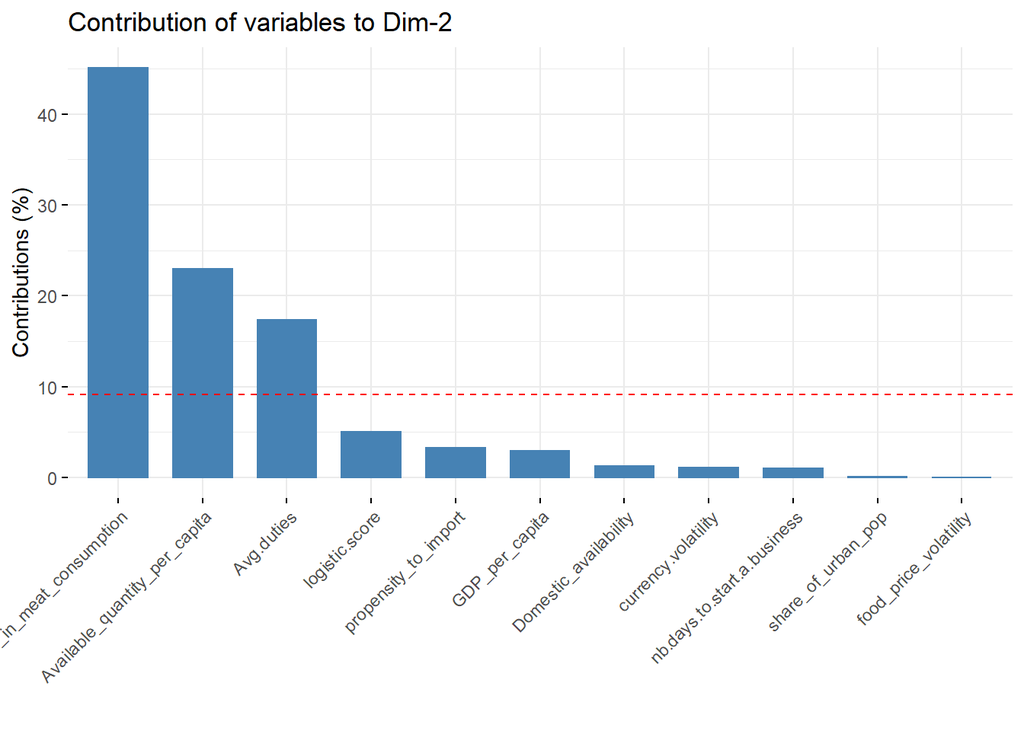

```r
fviz_contrib(res.PCA, choice = "var", axes = 2, top = 11)
```

```r
dimdesc <- dimdesc(res.PCA, axes=2, proba=0.05) #give correlation of variable to the dimension and p value
print(dimdesc$Dim.2)
```

```
## $quanti
##                                   correlation      p.value
## poultry_share_in_meat_consumption   0.8667850 6.542339e-50
## Available_quantity_per_capita       0.6188252 2.165271e-18
## Avg.duties                          0.5369455 2.095586e-13
## GDP_per_capita                     -0.2211590 4.812480e-03
## propensity_to_import               -0.2328176 2.958106e-03
## logistic.score                     -0.2900933 1.893745e-04
##
## attr(,"class")
## [1] "condes" "list"
```

- **dimension 3**: domestic market

**Coutries high on this axis are country that should be considered as big poultry meat producers**

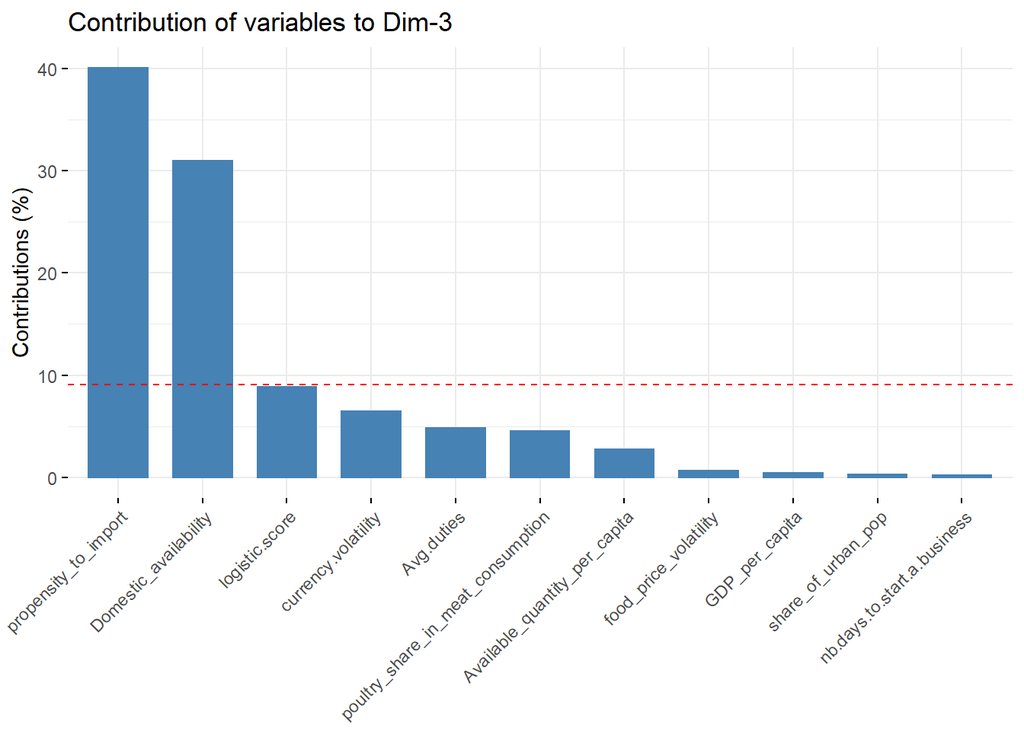

```r
fviz_contrib(res.PCA, choice = "var", axes = 3, top = 11)
```

```r
dimdesc <- dimdesc(res.PCA, axes=3, proba=0.05) #give correlation of variable to the dimension and p value
print(dimdesc$Dim.3)
```

```
## $quanti
##                                   correlation      p.value
## Domestic_availability               0.6388481 7.647281e-20
## logistic.score                      0.3417906 9.104139e-06
## currency.volatility                 0.2916192 1.745103e-04
## Avg.duties                          0.2520431 1.258041e-03
## Available_quantity_per_capita      -0.1897572 1.591170e-02
## poultry_share_in_meat_consumption  -0.2437526 1.833776e-03
## propensity_to_import               -0.7270161 9.431954e-28
##
## attr(,"class")
## [1] "condes" "list"
```

- **dimension 4** : trade accessibility

**Countries high on this axis might be considered as difficult to make business with** as they would need currency hedging and high settlement cost.

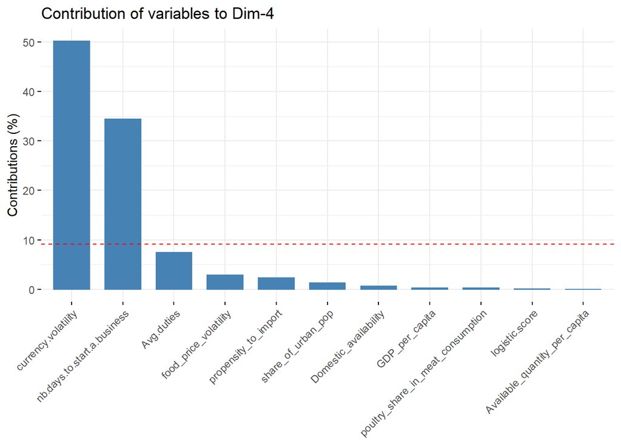

```r
fviz_contrib(res.PCA, choice = "var", axes = 4, top = 11)
```

```r
dimdesc <- dimdesc(res.PCA, axes=4, proba=0.05) #give correlation of variable to the dimension and p value
print(dimdesc$Dim.4)
```

```
## $quanti
##                             correlation      p.value
## currency.volatility           0.7355255 1.111689e-28
## nb.days.to.start.a.business   0.6092691 9.829952e-18
## propensity_to_import          0.1587920 4.422736e-02
## food_price_volatility        -0.1768274 2.483764e-02
## Avg.duties                   -0.2837008 2.653894e-04
##
## attr(,"class")
## [1] "condes" "list"
```

- **Dimension 5** : Food price volatility

As a matter of fact, a country high on this axis could present a risk for us as our selling prices would be fairly uncertain.

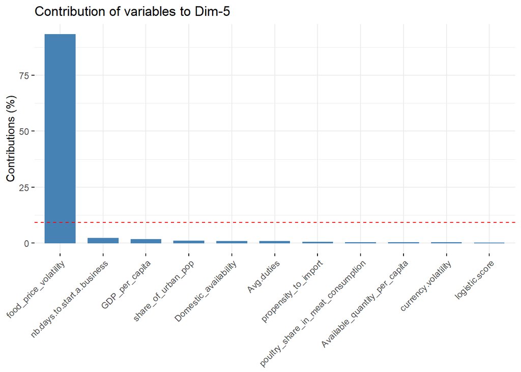

```r
fviz_contrib(res.PCA, choice = "var", axes = 5, top = 11)
```

```r
dimdesc <- dimdesc(res.PCA, axes=5, proba=0.05) #give correlation of variable to the dimension and p value
print(dimdesc$Dim.5)
```

```
## $quanti
##                       correlation      p.value
## food_price_volatility    0.951063 5.306042e-83
##
## attr(,"class")
## [1] "condes" "list"
```

- **Dimension 6** : international trade risk

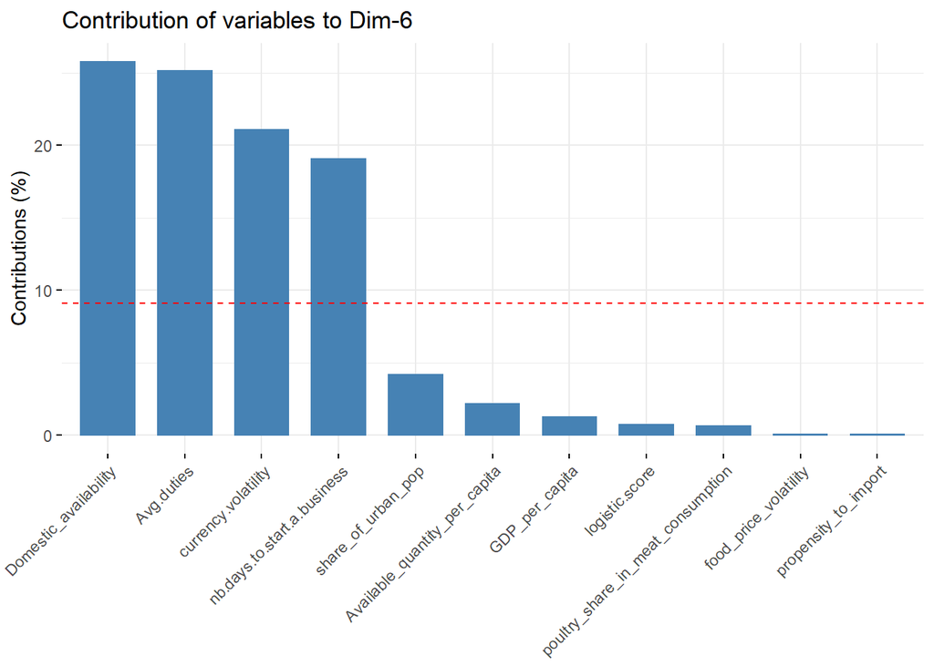

```r
fviz_contrib(res.PCA, choice = "var", axes = 6, top = 11)
```

```r
dimdesc <- dimdesc(res.PCA, axes=6, proba=0.05) #give correlation of variable to the dimension and p value
print(dimdesc$Dim.6)
```

```
## $quanti
##                             correlation      p.value
## Avg.duties                    0.4634563 5.976989e-10
## currency.volatility           0.4242341 2.045001e-08
## share_of_urban_pop            0.1881242 1.685722e-02
## nb.days.to.start.a.business  -0.4037386 1.091515e-07
## Domestic_availability        -0.4694637 3.340915e-10
##
## attr(,"class")
## [1] "condes" "list"
```

### Individus

```r
pays <- get_pca_ind(res.PCA)
print("development, poultry appetence")
```

```
## [1] "development, poultry appetence"
```

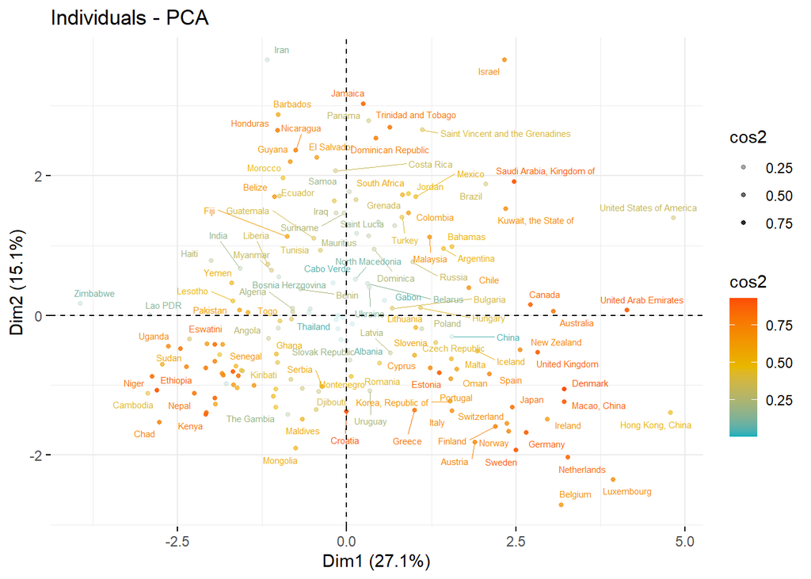

```r
fviz_pca_ind (res.PCA, col.ind = "cos2",
              gradient.cols = c("#00AFBB", "#E7B800", "#FC4E07"), labelsize=2, pointsize=1, alpha.ind = "cos2",
              repel = TRUE )
```

```r
print("development, domestic market")
```

```
## [1] "development, domestic market"
```

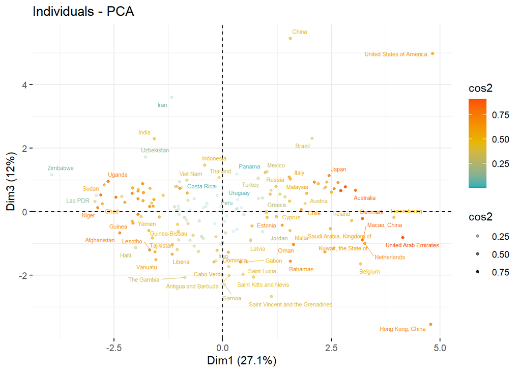

```r
fviz_pca_ind (res.PCA, col.ind = "cos2", axes=c(1,3),
              gradient.cols = c("#00AFBB", "#E7B800", "#FC4E07"), labelsize=2, pointsize=1, alpha.ind = "cos2",
              repel = TRUE )
```

```r
print("development, trade accessibility")
```

```
## [1] "development, trade accessibility"
```

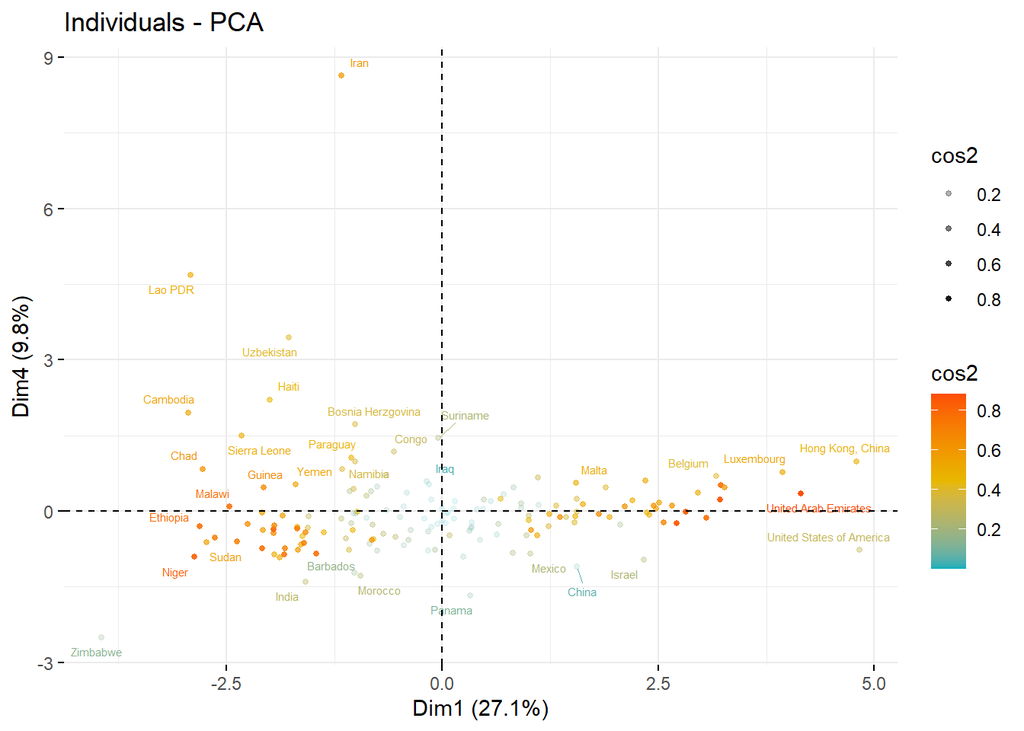

```r
fviz_pca_ind (res.PCA, col.ind = "cos2", axes=c(1,4),
              gradient.cols = c("#00AFBB", "#E7B800", "#FC4E07"), labelsize=2, pointsize=1, alpha.ind = "cos2",
              repel = TRUE )
```

```r
print("development, food price volatility")
```

```
## [1] "development, food price volatility"
```

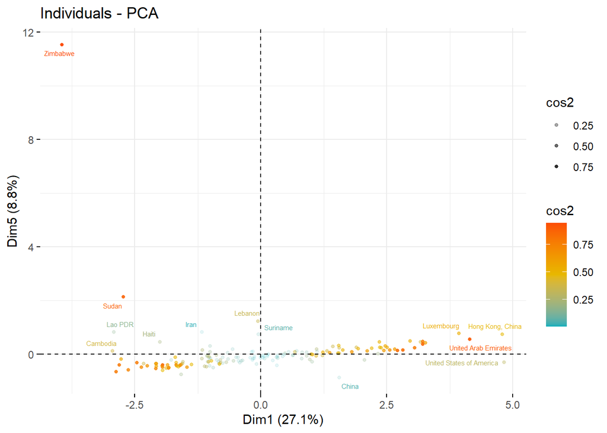

```r
fviz_pca_ind (res.PCA, col.ind = "cos2", axes=c(1,5),
              gradient.cols = c("#00AFBB", "#E7B800", "#FC4E07"), labelsize=2, pointsize=1, alpha.ind = "cos2",
              repel = TRUE )
```

This is a bite fuzzy, we need to reduce individual numbers.

## Hierarchical Clustering on Principal Components

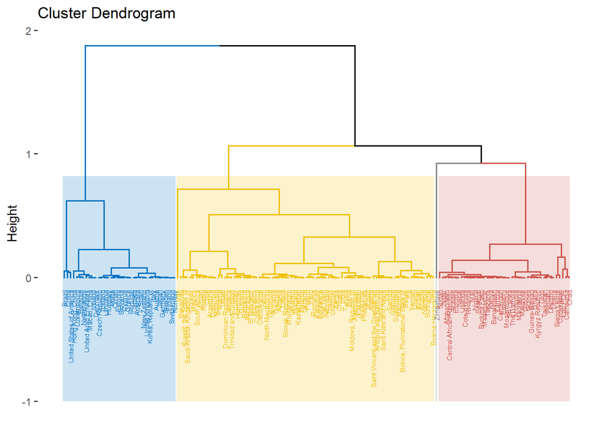

```r
res.hcpc <- HCPC(res.PCA,nb.clust=4,graph = FALSE)

fviz_dend(res.hcpc,
          cex = 0.4,
          palette = "jco",
          rect = TRUE, rect_fill = TRUE,
          rect_border = "jco",
          labels_track_height = 0.5
          )
```

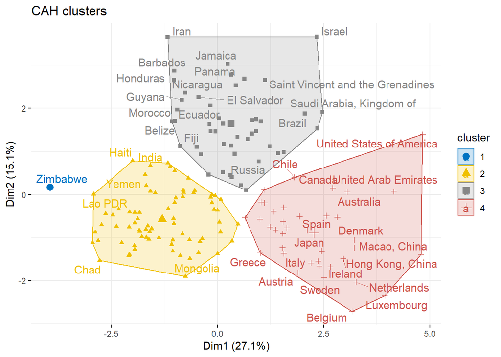

```r
fviz_cluster(res.hcpc,
             repel = TRUE,
             show.clust.cent = TRUE, #show cluster center
             palette = "jco",
             ggtheme = theme_minimal(),
             main = "CAH clusters"
             )
```

With this classification we find 3 relevant clusters that we can sum up as developed countries, emerging countries and developing countries.

```r
res.hcpc$desc.var$quanti
```

```
## $`1`
##                        v.test Mean in category Overall mean sd in category
## food_price_volatility 12.2969         1740.054     17.86942              0
##                       Overall sd      p.value
## food_price_volatility   140.0503 9.411309e-35
##
## $`2`
##                                      v.test Mean in category Overall mean
## nb.days.to.start.a.business        2.296085       22.0573333 1.803168e+01
## Domestic_availability             -2.276882      274.9466667 7.059565e+02
## logistic.score                    -5.985479        2.5911966 2.862184e+00
## poultry_share_in_meat_consumption -7.189642        0.1879975 2.852106e-01
## GDP_per_capita                    -7.234312     7733.9973333 1.932535e+04
## share_of_urban_pop                -7.245185       45.9476267 5.935672e+01
## Available_quantity_per_capita     -9.252877        7.8581333 2.028708e+01
##                                   sd in category   Overall sd      p.value
## nb.days.to.start.a.business           26.1308001 2.071048e+01 2.167104e-02
## Domestic_availability                598.6257572 2.236084e+03 2.279326e-02
## logistic.score                         0.3003070 5.348010e-01 2.157546e-09
## poultry_share_in_meat_consumption      0.1089548 1.597198e-01 6.496129e-13
## GDP_per_capita                      6899.0572240 1.892684e+04 4.678935e-13
## share_of_urban_pop                    17.1600409 2.186207e+01 4.318506e-13
## Available_quantity_per_capita          6.1692653 1.586715e+01 2.185302e-20
##
## $`3`
##                                      v.test Mean in category Overall mean
## poultry_share_in_meat_consumption  9.758652        0.4771182    0.2852106
## Available_quantity_per_capita      7.722416       35.3738298   20.2870807
## Avg.duties                         4.460522       37.2345069   23.9583629
## share_of_urban_pop                 2.049762       64.8741702   59.3567205
## logistic.score                    -2.714459        2.6834455    2.8621844
##                                   sd in category Overall sd      p.value
## poultry_share_in_meat_consumption      0.0981293  0.1597198 1.693921e-22
## Available_quantity_per_capita         14.1824978 15.8671514 1.141451e-14
## Avg.duties                            33.0488658 24.1736778 8.176013e-06
## share_of_urban_pop                    19.5460186 21.8620746 4.038763e-02
## logistic.score                         0.2929743  0.5348010 6.638420e-03
##
## $`4`
##                                  v.test Mean in category Overall mean
## logistic.score                10.194343     3.637632e+00 2.862184e+00
## GDP_per_capita                10.083103     4.646930e+04 1.932535e+04
## share_of_urban_pop             6.546202     7.971221e+01 5.935672e+01
## Available_quantity_per_capita  2.783369     2.656868e+01 2.028708e+01
## Domestic_availability          2.296732     1.436421e+03 7.059565e+02
## propensity_to_import           2.149493     5.806246e-01 4.307824e-01
## nb.days.to.start.a.business   -3.187534     8.642105e+00 1.803168e+01
## Avg.duties                    -4.680857     7.864181e+00 2.395836e+01
##                               sd in category   Overall sd      p.value
## logistic.score                      0.356883 5.348010e-01 2.101608e-24
## GDP_per_capita                  17531.558998 1.892684e+04 6.562021e-24
## share_of_urban_pop                 12.042261 2.186207e+01 5.901861e-11
## Available_quantity_per_capita      10.512655 1.586715e+01 5.379758e-03
## Domestic_availability            4004.450653 2.236084e+03 2.163406e-02
## propensity_to_import                0.647804 4.901143e-01 3.159537e-02
## nb.days.to.start.a.business         7.176740 2.071048e+01 1.434916e-03
## Avg.duties                         11.779788 2.417368e+01 2.856777e-06
```

```r
res.hcpc$desc.axes$quanti
```

```
## $`1`
##          v.test Mean in category  Overall mean sd in category Overall sd
## Dim.5 11.722935        11.542471 -1.891630e-16              0  0.9846059
## Dim.1 -2.281336        -3.942420 -1.608574e-15              0  1.7281191
## Dim.4 -2.410275        -2.502173 -2.101494e-16              0  1.0381277
##            p.value
## Dim.5 9.724315e-32
## Dim.1 2.252859e-02
## Dim.4 1.594050e-02
##
## $`2`
##          v.test Mean in category  Overall mean sd in category Overall sd
## Dim.5 -2.521479       -0.2101727 -1.891630e-16      0.4078877  0.9846059
## Dim.2 -5.280719       -0.5769665  7.863038e-16      0.6070151  1.2906217
## Dim.1 -8.878003       -1.2988159 -1.608574e-15      0.8674750  1.7281191
##            p.value
## Dim.5 1.168628e-02
## Dim.2 1.286779e-07
## Dim.1 6.807111e-19
##
## $`3`
##         v.test Mean in category Overall mean sd in category Overall sd
## Dim.2 10.32898         1.641345 7.863038e-16      0.8373036   1.290622
##            p.value
## Dim.2 5.211327e-25
##
## $`4`
##          v.test Mean in category  Overall mean sd in category Overall sd
## Dim.1  9.228871        2.2684178 -1.608574e-15      1.0409908   1.728119
## Dim.3  2.037131        0.3327448 -7.534087e-16      1.4686902   1.148396
## Dim.2 -4.879640       -0.8957514  7.863038e-16      0.8190031   1.290622
##            p.value
## Dim.1 2.734983e-20
## Dim.3 4.163695e-02
## Dim.2 1.062798e-06
```

If we drop cluster 1 as it is only concerning Zimbabwe, we see that :

- cluster 2 (developing countries) is most influence by the 2 first dimensions more specifically and by food price volatility (dim5). This cluster gathers countries with low GDP per capita, logistic score, share of urban population (dim1), available quantity per capita (dim1&2), poultry share in meat consumption (dim2) and domestic availability (dim3)
- cluster 3 (emerging countries) is mostly influence per dimension 2
- cluster 4 (developed countries) is well represented on dimensions 1, 3 and 2.

### looking to paragones

```r
res.hcpc$desc.ind$para
```

```
## Cluster: 1
##  Zimbabwe
##         0
## ------------------------------------------------------------
## Cluster: 2
## Mozambique      Ghana   Eswatini   Cameroon     Zambia
##  0.6441184  0.7558403  0.8067122  0.8558653  0.8674227
## ------------------------------------------------------------
## Cluster: 3
##    Jordan Mauritius  Colombia Guatemala   Tunisia
## 0.7318391 0.9427104 0.9479238 1.2239058 1.3068816
## ------------------------------------------------------------
## Cluster: 4
##          Spain       Portugal    New Zealand United Kingdom          Japan
##      0.6985145      0.7698195      0.7815263      0.8516526      0.9217428
```

Those countries are the closest from cluster center.

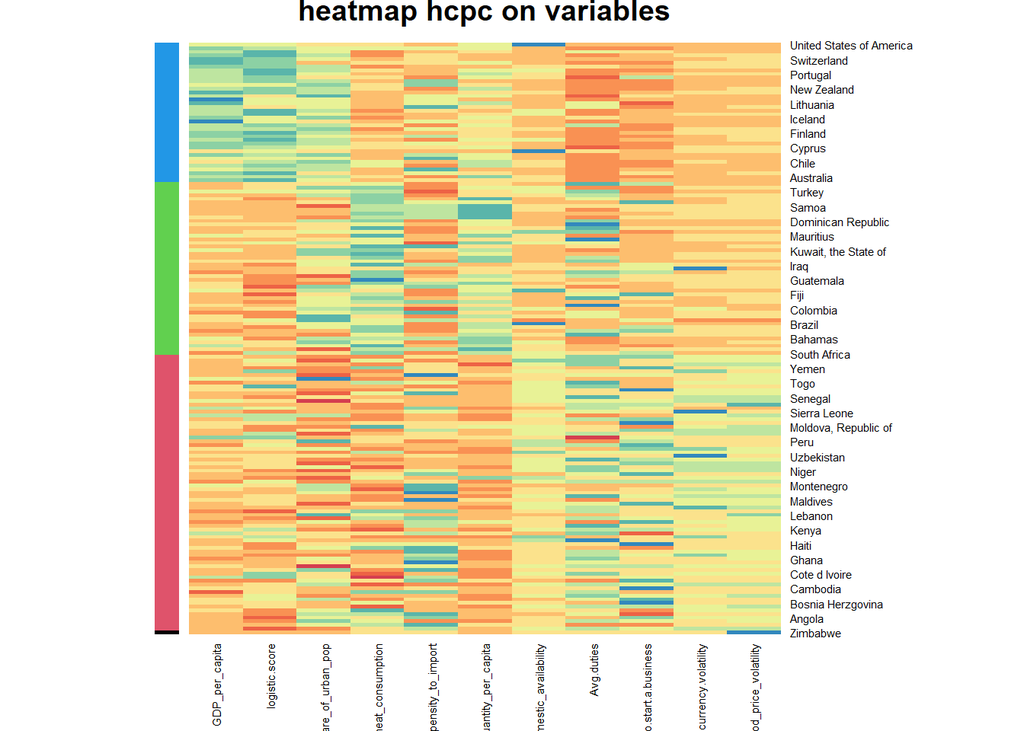

```r
clust.table <- res.hcpc$data.clust
clust.table <- clust.table[,c(5,9,8,7,3,1,2,4,10,6,11,12)]#reorganise column
C2 <- subset(clust.table, clust.table$clust==2)
C3 <- subset(clust.table, clust.table$clust==3)
C4 <- subset(clust.table, clust.table$clust==4)
clust.table<-clust.table[order(clust.table$clust),]
palette <- colorRampPalette(brewer.pal(8, "Spectral"))(10)

heatmap(scale(clust.table[,1:11]),  Colv =NA, Rowv=NA, RowSideColors = as.character(clust.table$clust), cexRow = 0.7, cexCol = 0.7 , main="heatmap hcpc on variables", col=palette)
```

With this classification method, we could discard cluster 1 and 2. We, then can focus on countries like France (cluster 4) or countries a bite further with a least developed economy but a seems to be good poultry market. Before we go further down the analyse, let’s check which result we get with an other classification method.

## Kmean

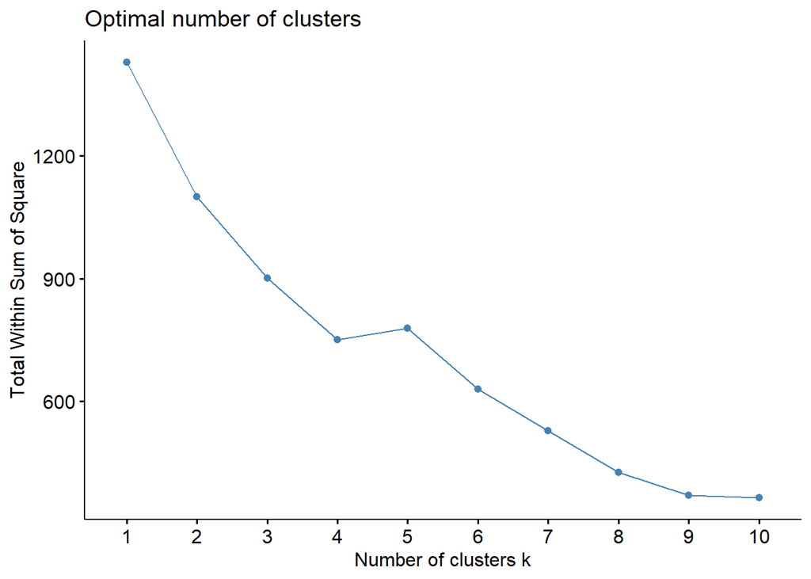

```r
fviz_nbclust(res.PCA$ind$coord, kmeans, method = 'wss') # we target compacity
```

```r
set.seed(111)
res.km <- kmeans(scale(res.PCA$ind$coord), centers = 4, nstart = 25)
res.km$size
```

```
## [1] 75  1 48 37
```

```r
res.km$centers
```

```
##        Dim.1      Dim.2        Dim.3       Dim.4       Dim.5       Dim.6
## 1 -0.7352768 -0.4586988 -0.007350718  0.01036866 -0.21101655 -0.04315482
## 2 -2.2742398  0.1296442  1.008065323 -2.40277809 11.68647197  0.19411416
## 3  0.1680779  1.2530904 -0.254256647 -0.01569386 -0.04723294  0.02877336
## 4  1.3338449 -0.6993398  0.317501555  0.06428200  0.17316082  0.04490205
```

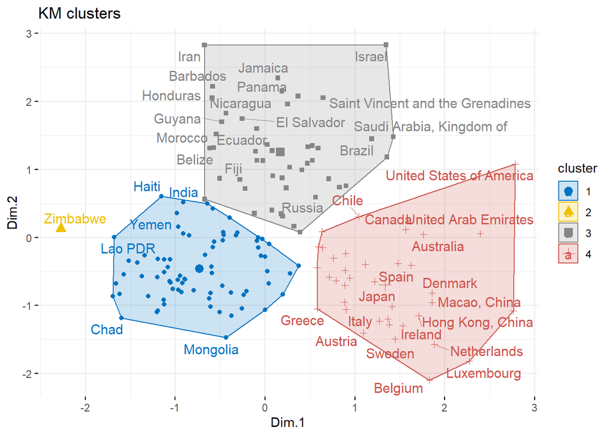

```r
fviz_cluster(res.km,res.PCA$ind$coord[,1:2],
             repel = TRUE,
             show.clust.cent = TRUE, #show cluster center
             palette = "jco",
             ggtheme = theme_minimal(),
             main = "KM clusters"
             )
```

```r
clust.table <-merge(clust.table, res.km$cluster, by=0)
```

So both classification method lead to equivalent results.

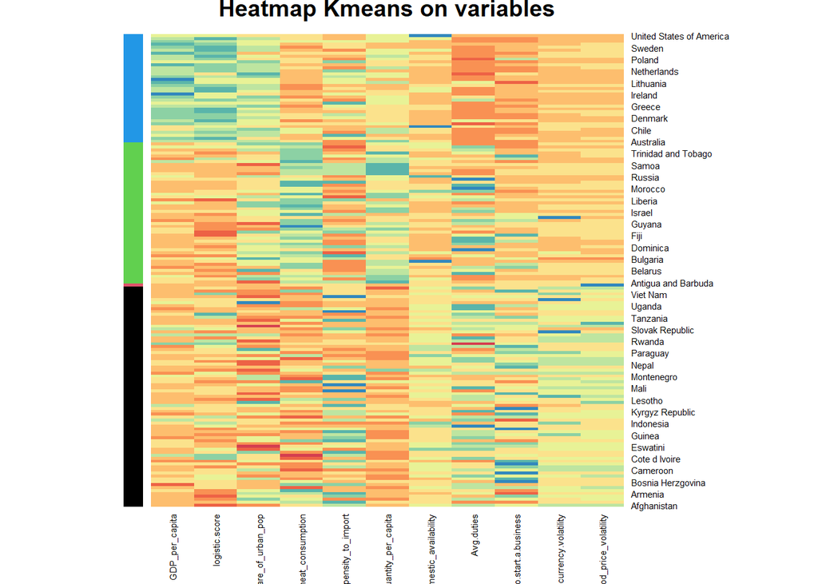

```r
clust.table<-clust.table[order(clust.table$y),]
rownames(clust.table)<-clust.table$Row.names
clust.table<-clust.table[,2:14]
heatmap(scale(scale(clust.table[,1:11])),col= palette, Colv=NA, Rowv = NA, cexRow = 0.7, cexCol = 0.7 ,main="Heatmap Kmeans on variables", RowSideColors =as.character(clust.table[,13]),
        )
```

## Recommandations

```r
data(country.map, package = "choroplethrMaps")
head(unique(country.map$region), 5)#countries name are in lowercase
```

```
## [1] "afghanistan" "angola"      "azerbaijan"  "moldova"     "madagascar"
```

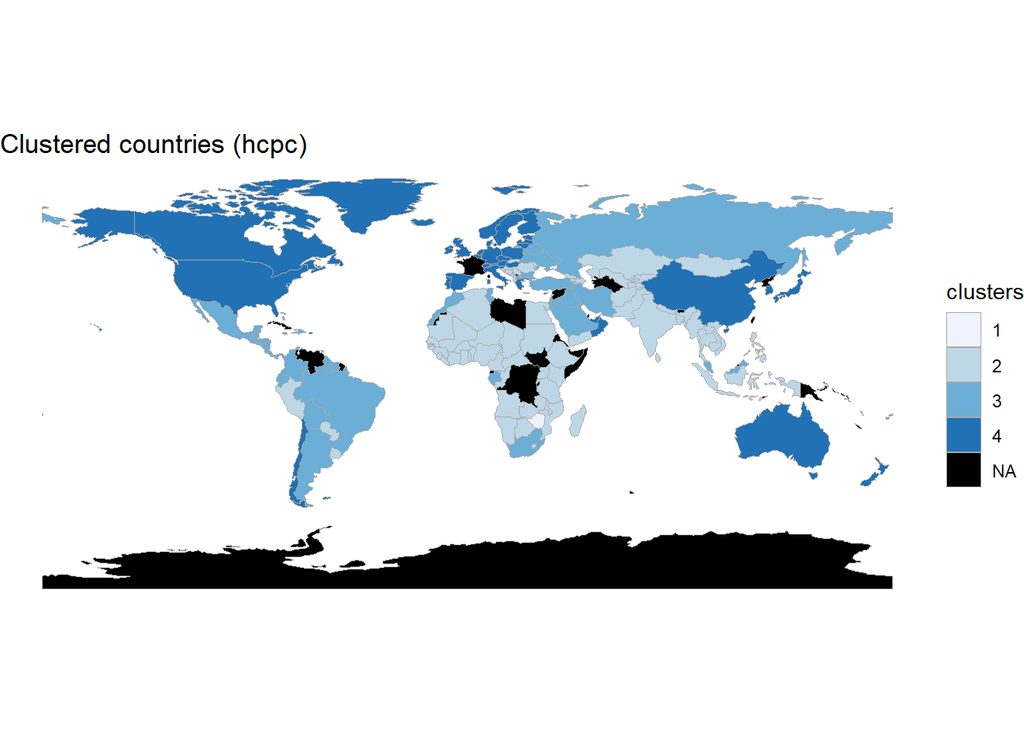

```r
clust.table$region <- rownames(clust.table)
clust.table <- mutate(clust.table ,region = tolower(region)) #create a region column from rowname and convert to lowercase

clust.table <- mutate(clust.table,region = recode(region,
     "saudi arabia, kingdom of"="saudi arabia",
     "bolivia, plurinational state of"="bolivia",
     "bosnia herzgovina"="bosnia and herzegovina",
     "congo"="republic of congo",
     "cote d ivoire" ="ivory coast",
     "bahamas"="the bahamas",
     "eswatini"="swaziland",
     "the gambia"="gambia",
     "guinea-bissau" ="guinea bissau",
     "kyrgyz republic"  ="kyrgyzstan",
     "kuwait, the state of" ="kuwait",
     "north macedonia"="macedonia",
     "korea, republic of"="south korea",
     "moldova, republic of" ="moldova",
     "lao pdr"="laos",
     "tanzania"="united republic of tanzania",
     "serbia"="republic of serbia",
     "slovak republic"="slovakia",
     "viet nam" ="vietnam"
))
#setdiff(clust.table$region,unique(country.map$region))
#setdiff(unique(country.map$region), clust.table$region)


df<-filter(clust.table,
      clust.table$region != "antigua and barbuda"&
      clust.table$region!="barbados"&
      clust.table$region!="cabo verde"&
      clust.table$region!="hong kong, china"&
      clust.table$region!="macao, china"&
      clust.table$region!="dominica"&
      clust.table$region!="grenada"&
      clust.table$region!="kiribati"&
      clust.table$region!="maldives"&
      clust.table$region!="malta"&
      clust.table$region!="mauritius"&
      clust.table$region!="saint kitts and nevis"&
      clust.table$region!="saint vincent and the grenadines"&
      clust.table$region!="saint lucia"&
      clust.table$region!="samoa")
df_hcpc<-df[,c("clust","region")]
colnames(df_hcpc)<-c("value","region")

country_choropleth(df_hcpc, title="Clustered countries (hcpc)", legend="clusters",)
```

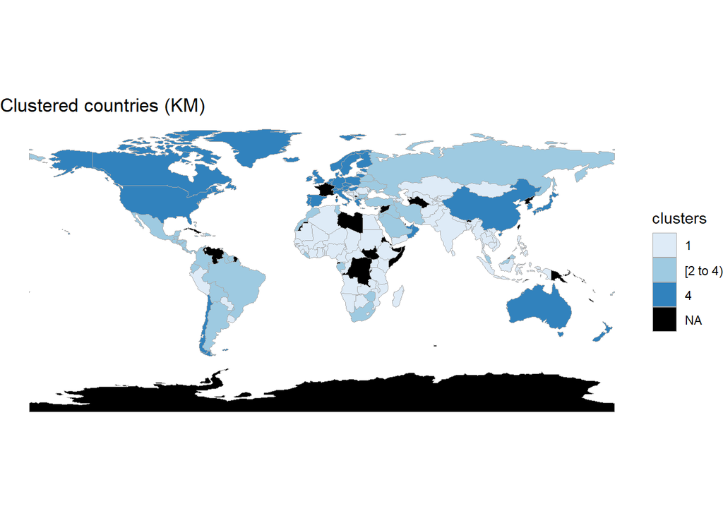

```r
df_km<-df[,c("y","region")]
colnames(df_km)<-c("value","region")
country_choropleth(df_km, title="Clustered countries (KM)", legend="clusters",)
```

Looking at cluster 3 (~emerging countries ) and 4 ( ~ developed countries) we can reduce our dataset from 161 countries to 85 : 46 for cluster 3 and 39 for cluster 4.

Before going further in our analysis, some countries have to be ruled out for obvious reasons.

- in cluster 3 :
- Belarus, Russia and Ukraine currently at war cannot be considered as proper prospect.
- Brazil as the prime poultry exportator should be considered as too challenging.
- small islands (Antigua and Barbuda,Bahamas, Barbados…) should ruled out too as transportation cost would be very high

```r
C3$region <- rownames(C3)

df.C3<-subset(C3, C3$region!= "Belarus"&
         C3$region!="Russia"&
         C3$region!="Ukraine"&
         C3$region!="Antigua and Barbuda"&
         C3$region!="Bahamas"&
         C3$region!="Barbados"&
         C3$region!="Brazil"&
         C3$region!="Dominica"&
         C3$region!="Fiji"&
         C3$region!="Granada"&
         C3$region!="Saint Kitts and Nevis"&
       C3$region!="Saint Vincent and the Grenadines"&
         C3$region!="Saint Lucia"&
       C3$region!="Trinidad and Tobago")
```

This reduce our C3 cluster to 34 countries.

- in cluster 4 :

We should remove China and the USA as their market is to big to be considered as a whole.

```r
C4$region <- rownames(C4)
df.C4 <- subset(C4, C4$region != "China"& C4$region != "Hong Kong, China" & C4$region!= "Macao, China" & C4$region!= "United States of America")
```

This reduce our fourth cluster to 34 observations.

### Safe recommandation

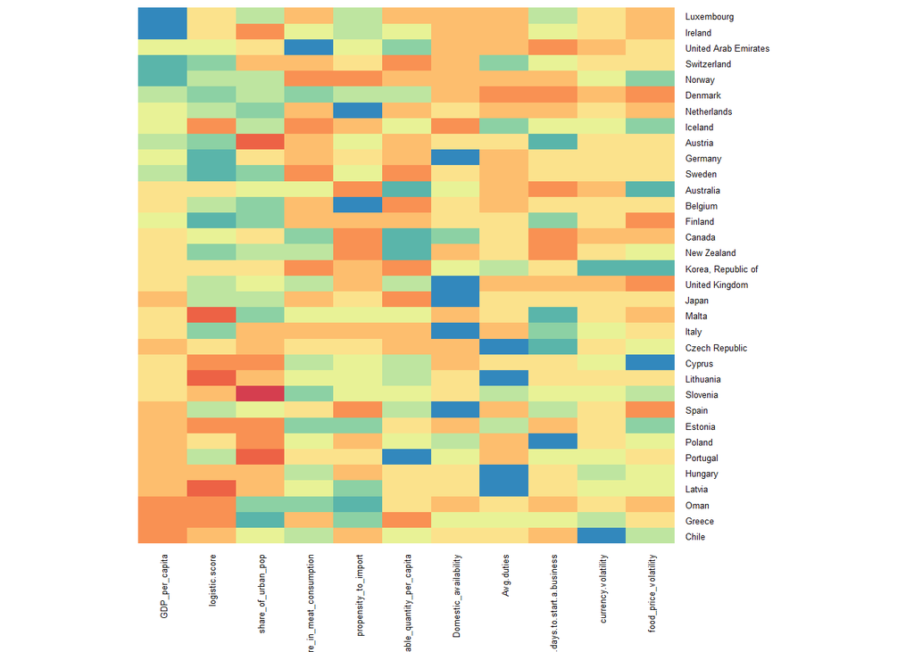

```r
df.C4<-df.C4[order(df.C4$GDP_per_capita, df.C4$share_of_urban_pop),]

heatmap(scale(df.C4[,1:11]),col= palette, Rowv=NA,Colv=NA, cexRow = 0.5, cexCol = 0.5)
```

If we are to export in country looking like France, we should look to countries with a good revenue per capita, eating and importing a lot of poultry, and with a high urban and logistic score so we can have a quick access to our customers. In the mean time, our target must be stable (currency and price) to limit our risk, with a low duties rate so we stay competitive and an easy settlement process is obviously a plus.

This means that we are looking for blue on the left side of the heatmap and orange on the right side.

Best candidates seem then to be:

- Denmark
- United Arab Emirates
- The Netherlands (ruled out as a major importation hub)

```r
a<-data[,c("global_population",'Influenza')]
a$region <- rownames(a)
subset(a, a$region=="United Arab Emirates"|a$region=="Denmark")
```

```
##                      global_population Influenza               region
## Denmark                       5752.126         1              Denmark
## United Arab Emirates          9630.959         1 United Arab Emirates
```

Denmark and United Arab Emirate offer reachable solvent market. Moreover both countries have experience aviary influenza this winter that can cause a call for air on their domestic market.

### Slightly riskier recommandation

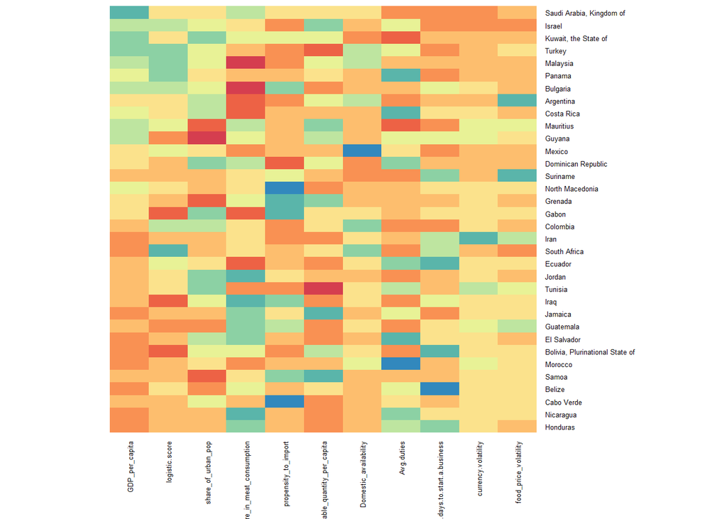

```r
df.c3<- df.C3[order(df.C3$GDP_per_capita),]
heatmap(scale(df.c3[,1:11]),col= palette, Rowv=NA,Colv=NA, cexRow = 0.5, cexCol = 0.5)
```

Then we should go for middle east to Israel, Kuwait or Saudi Arabia.

```r
b<-data[,c("global_population",'Influenza')]
b$region <- rownames(b)
subset(b, b$region=="Saudi Arabia, Kingdom of"|b$region=="Israel"|b$region=="Kuwait, the State of")
```

```
##                          global_population Influenza                   region
## Saudi Arabia, Kingdom of         33702.756         0 Saudi Arabia, Kingdom of
## Israel                            8381.516         0                   Israel
## Kuwait, the State of              4137.312         0     Kuwait, the State of
```

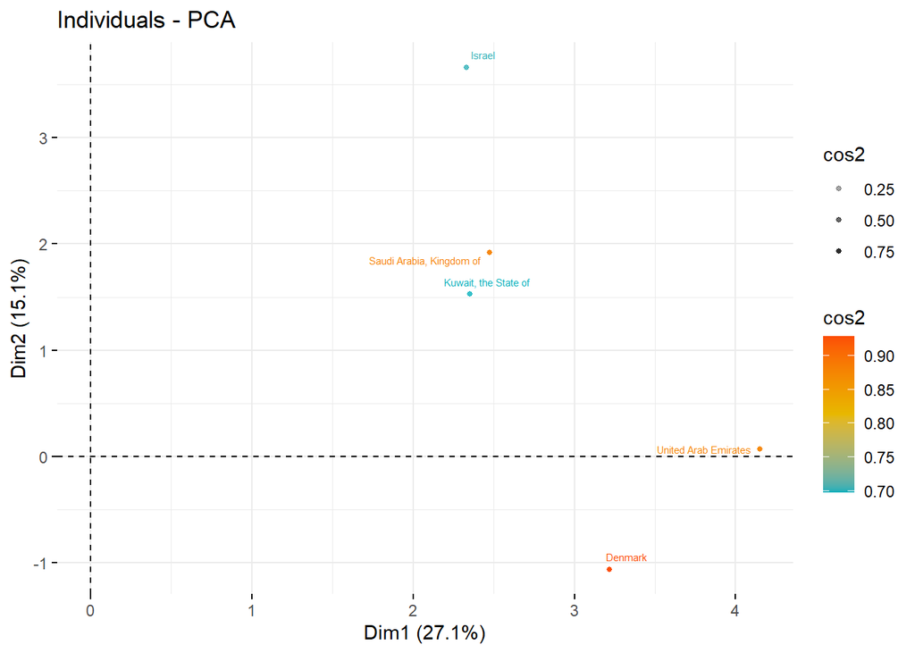

```r
fviz_pca_ind (res.PCA, col.ind = "cos2",
              gradient.cols = c("#00AFBB", "#E7B800", "#FC4E07"), labelsize=2, pointsize=1, alpha.ind = "cos2",
              repel = TRUE, select.ind =list(name= c("Saudi Arabia, Kingdom of","Israel","Kuwait, the State of","Denmark","United Arab Emirates")) )
```

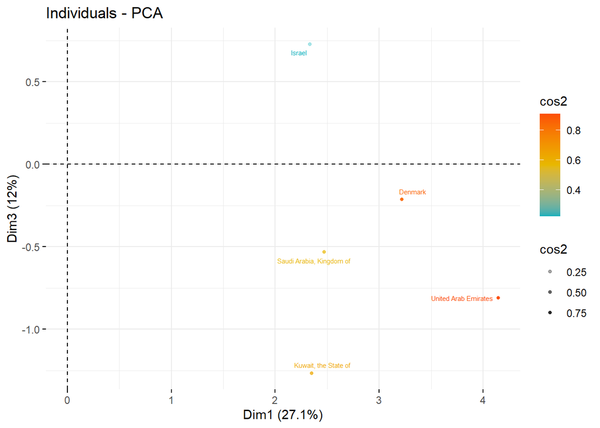

```r
fviz_pca_ind (res.PCA, col.ind = "cos2", axes=c(1,3),
              gradient.cols = c("#00AFBB", "#E7B800", "#FC4E07"), labelsize=2, pointsize=1, alpha.ind = "cos2",
              repel = TRUE ,select.ind =list(name= c("Saudi Arabia, Kingdom of","Israel","Kuwait, the State of","Denmark","United Arab Emirates")))
```

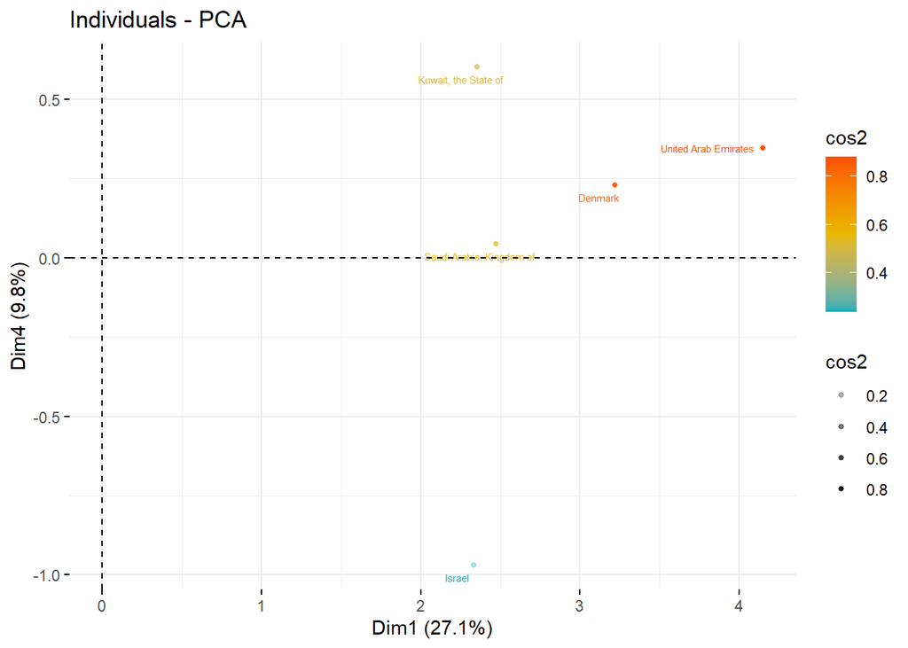

```r
fviz_pca_ind (res.PCA, col.ind = "cos2", axes=c(1,4),
              gradient.cols = c("#00AFBB", "#E7B800", "#FC4E07"), labelsize=2, pointsize=1, alpha.ind = "cos2",
              repel = TRUE, select.ind =list(name= c("Saudi Arabia, Kingdom of","Israel","Kuwait, the State of","Denmark","United Arab Emirates")))
```